# NgTET in vitro

Notice that the seqLogo library is from the bioconductor package. First install bioconductor, using the commend install.packages(“BiocManager”). Then install the seqLogo package using BiocManager::install(c(“seqLogo”)). Other packages will be installed automatically on request in rstudio if not present already.

```r
library(readxl)
library(tidyr)
library(purrr)
library(dplyr)
library(seqLogo)
options(digits=12)
```

```r
filename <-"../Datasets/nTet-CpN-FM-Compilation-Forward_kinetics.xlsx"
sheet <- "all"
range1 <- "E26:IY34"
range2 <- "E82:IY83"
range3 <- "E85:IY86"
name <- "NgTET"
```

```r
create_df <- function (filename, sheet, range1, range2, range3,name)
{
  options(digits=10)
  TET <- read_excel(filename, sheet = sheet, range = range1) %>% map_df(rev)
  names(TET)<-paste("seq",1:255)
  TET_v1 <- read_excel(filename, sheet = sheet, range = range2,col_types="text")
  names(TET_v1)<-paste("seq",1:255)
  TET_v2 <- read_excel(filename, sheet = sheet, range = range3,col_types="text")
  names(TET_v2)<-paste("seq",1:255)
  TET_all1 <- rbind(TET,TET_v1,TET_v2)
  TET_all2 <- as.data.frame(t(TET_all1))
}
```

```r
shortlogo <- function(model_simple) {
  mycoeff <- coef(summary(model_simple))
  V3_A <-1
  V3_C <-exp(mycoeff["V3C","Estimate"])
  V3_G <-exp(mycoeff["V3G","Estimate"])
  V3_T <-exp(mycoeff["V3T","Estimate"])
  unV3 <-c(V3_A,V3_C,V3_G, V3_T)
  fact <- sum(c(V3_A,V3_C,V3_G, V3_T))
  myV3 <- unV3/fact
  #
  myV4 <- c(0.0,1.0,0.0,0.0)
  #
  V5_A <-1
  V5_C <-exp(mycoeff["V5C","Estimate"])
  V5_G <-exp(mycoeff["V5G","Estimate"])
  V5_T <-exp(mycoeff["V5T","Estimate"])
  unV5 <-c(V5_A,V5_C,V5_G, V5_T)
  fact <- sum(c(V5_A,V5_C,V5_G, V5_T))
  myV5 <- unV5/fact
  #
  V6_A <-1
  V6_C <-exp(mycoeff["V6C","Estimate"])
  V6_G <-exp(mycoeff["V6G","Estimate"])
  V6_T <-exp(mycoeff["V6T","Estimate"])
  unV6 <-c(V6_A,V6_C,V6_G, V6_T)
  fact <- sum(c(V6_A,V6_C,V6_G, V6_T))
  myV6 <- unV6/fact
  logo_input=data.frame(myV3,myV4,myV5,myV6)
  p <- makePWM(logo_input)
  seqLogo(p, ic.scale=FALSE)
}
```

```r
longlogo <-function(model_complex_sample)
{
  mycoeff <- coef(summary(model_complex_sample))
  #
  V2_A <-1
  V2_C <-exp(mycoeff["V2C","Estimate"])
  V2_G <-exp(mycoeff["V2G","Estimate"])
  V2_T <-exp(mycoeff["V2T","Estimate"])
  unV2 <-c(V2_A,V2_C,V2_G, V2_T)
  fact <- sum(c(V2_A,V2_C,V2_G, V2_T))
  myV2 <- unV2/fact
  #
  V3_A <-1
  V3_C <-exp(mycoeff["V3C","Estimate"])
  V3_G <-exp(mycoeff["V3G","Estimate"])
  V3_T <-exp(mycoeff["V3T","Estimate"])
  unV3 <-c(V3_A,V3_C,V3_G, V3_T)
  fact <- sum(c(V3_A,V3_C,V3_G, V3_T))
  myV3 <- unV3/fact
  #
  myV4 <- c(0.0,1.0,0.0,0.0)
  #
  V5_A <-1
  V5_C <-exp(mycoeff["V5C","Estimate"])
  V5_G <-exp(mycoeff["V5G","Estimate"])
  V5_T <-exp(mycoeff["V5T","Estimate"])
  unV5 <-c(V5_A,V5_C,V5_G, V5_T)
  fact <- sum(c(V5_A,V5_C,V5_G, V5_T))
  myV5 <- unV5/fact
  #
  V6_A <-1
  V6_C <-exp(mycoeff["V6C","Estimate"])
  V6_G <-exp(mycoeff["V6G","Estimate"])
  V6_T <-exp(mycoeff["V6T","Estimate"])
  unV6 <-c(V6_A,V6_C,V6_G, V6_T)
  fact <- sum(c(V6_A,V6_C,V6_G, V6_T))
  myV6 <- unV6/fact
  #
  V7_A <-1
  V7_C <-exp(mycoeff["V7C","Estimate"])
  V7_G <-exp(mycoeff["V7G","Estimate"])
  V7_T <-exp(mycoeff["V7T","Estimate"])
  unV7 <-c(V7_A,V7_C,V7_G, V7_T)
  fact <- sum(c(V7_A,V7_C,V7_G, V7_T))
  myV7 <- unV7/fact
  logo_input=data.frame(myV2,myV3,myV4,myV5,myV6,myV7)
  p <- makePWM(logo_input)
  seqLogo(p, ic.scale=FALSE)
}
```

## read in the data

```r
TET=create_df(filename, sheet, range1, range2, range3,name)
```

[output not shown]

[output not shown]

```r
TET$V9 <-as.numeric(as.character(TET$V9))
TET$V10 <-as.numeric(as.character(TET$V10))
```

## Compare the two experimental repeats

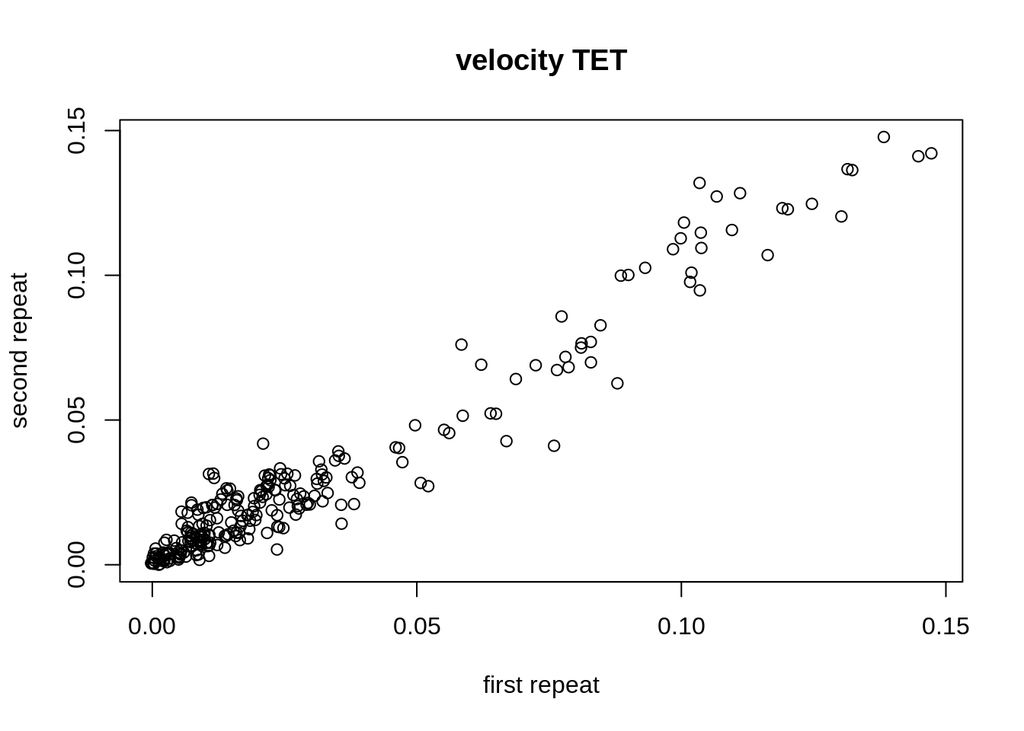

```r
options(digits=8)
plot(TET$V9,TET$V10,main="velocity TET", xlab="first repeat",ylab="second repeat")
```

## Remove negative or extremely low velocities

```r
TET_clean <- TET %>% drop_na()  %>% filter(V9>exp(-12)) %>% filter(V10>exp(-12))
TET_clean <- TET_clean %>% mutate(logV9=log(V9), logV10=log(V10))
TET_clean <- TET_clean %>% mutate(avlogV=(logV9+logV10)/2)
TET_clean <- TET_clean %>% mutate(difflogV=abs(logV9-logV10))
head(TET_clean)
```

```
##       V1 V2 V3 V4 V5 V6 V7 V8            V9          V10      logV9     logV10
## seq 1  A  T  T  C  G  C  C  C 5.5150606e-02 0.0466066820 -2.8976876 -3.0660114
## seq 2  T  C  G  C  C  C  T  T 9.3289472e-05 0.0025565365 -9.2798033 -5.9691019
## seq 3  C  G  C  C  C  T  T  T 1.3725106e-02 0.0058642885 -4.2885286 -5.1388741
## seq 4  G  C  C  C  T  T  T  G 6.3644629e-03 0.0028113786 -5.0570254 -5.8740803
## seq 5  G  G  G  C  T  G  C  T 4.9593111e-03 0.0018062885 -5.3064884 -6.3164811
## seq 6  C  T  G  C  T  G  G  A 3.3425757e-03 0.0013736615 -5.7010136 -6.5902755
##           avlogV   difflogV
## seq 1 -2.9818495 0.16832381
## seq 2 -7.6244526 3.31070143
## seq 3 -4.7137014 0.85034554
## seq 4 -5.4655529 0.81705487
## seq 5 -5.8114848 1.00999265
## seq 6 -6.1456445 0.88926188
```

## Compare log velocities

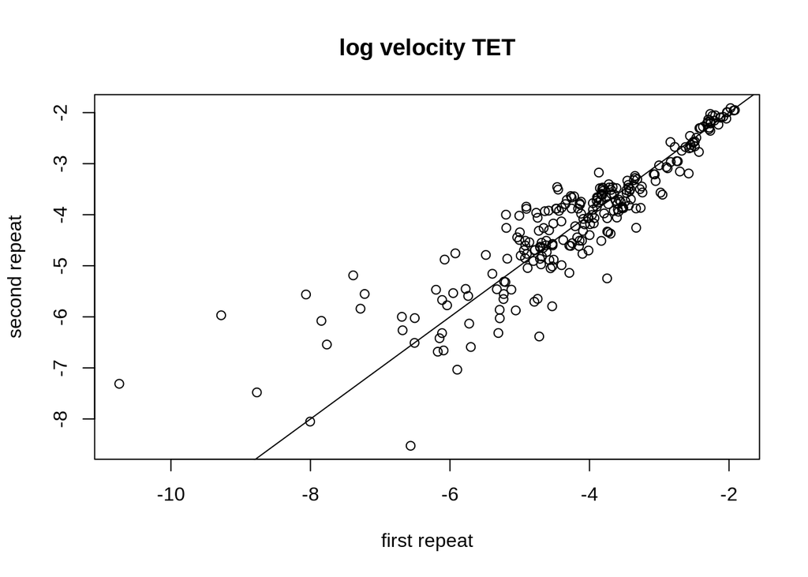

```r
plot(TET_clean$logV9,TET_clean$logV10,main="log velocity TET", xlab="first repeat",ylab="second repeat")
abline(a=0,b=1)
```

Notice that the error here looks like it could well be random

```r
cor(TET_clean$logV9,TET_clean$logV10)
```

```
## [1] 0.89195363
```

## Build a model with three contributing bases and weighting (and C)

```r
model_simple <-lm(avlogV~V3+V5+V6,data=TET_clean,weights=1/(difflogV+0.1))
summary(model_simple)
```

```
##
## Call:
## lm(formula = avlogV ~ V3 + V5 + V6, data = TET_clean, weights = 1/(difflogV +
##     0.1))
##
## Weighted Residuals:
##      Min       1Q   Median       3Q      Max
## -5.51649 -0.90396  0.00490  0.78278  3.58282
##
## Coefficients:
##             Estimate Std. Error  t value  Pr(>|t|)
## (Intercept) -2.66279    0.13582 -19.6056 < 2.2e-16 ***
## V3C         -1.07562    0.12697  -8.4716 2.495e-15 ***
## V3G         -1.22740    0.12355  -9.9341 < 2.2e-16 ***
## V3T         -0.29605    0.12261  -2.4146  0.016507 *
## V5C         -1.45752    0.11890 -12.2586 < 2.2e-16 ***
## V5G          0.39283    0.12117   3.2419  0.001357 **
## V5T         -1.04098    0.11963  -8.7019 5.398e-16 ***
## V6C          0.17468    0.12869   1.3574  0.175937
## V6G         -0.62567    0.13853  -4.5164 9.888e-06 ***
## V6T          0.66884    0.13934   4.8000 2.797e-06 ***
## ---
## Signif. codes:  0 '***' 0.001 '**' 0.01 '*' 0.05 '.' 0.1 ' ' 1
##
## Residual standard error: 1.2416 on 239 degrees of freedom
## Multiple R-squared:  0.69171,    Adjusted R-squared:  0.6801
## F-statistic: 59.582 on 9 and 239 DF,  p-value: < 2.22e-16
```

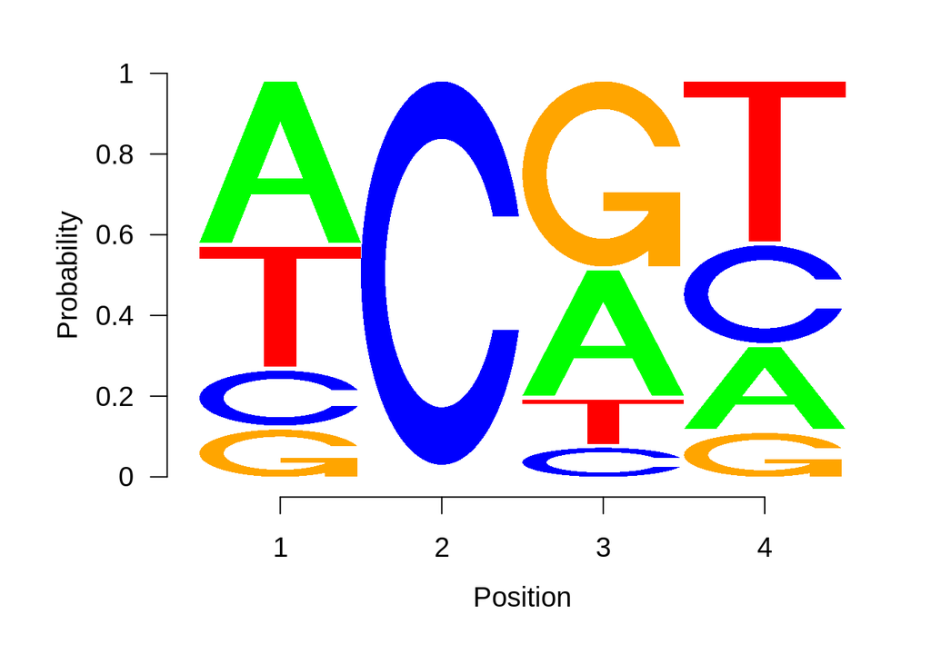

```r
shortlogo(model_simple)
```

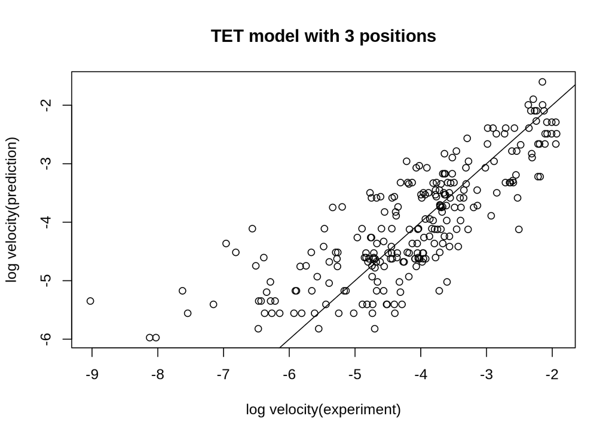

```r
plot(TET_clean$avlogV,as.vector(model_simple$fitted.values),
     main="TET model with 3 positions",
     xlab="log velocity(experiment)",
     ylab="log velocity(prediction)"
     )
abline(a=0,b=1)
```

```r
cor(TET_clean$avlogV,as.vector(model_simple$fitted.values))
```

```
## [1] 0.79180084
```

## Create a model with five contributing bases and weighting

```r
model_complex <-lm(avlogV~V2+V3+V5+V6+V7,data=TET_clean, weights=1/(difflogV+0.1))
summary(model_complex)
```

```
##
## Call:
## lm(formula = avlogV ~ V2 + V3 + V5 + V6 + V7, data = TET_clean,
##     weights = 1/(difflogV + 0.1))
##
## Weighted Residuals:
##      Min       1Q   Median       3Q      Max
## -4.58200 -0.65979 -0.14293  0.43465  2.86732
##
## Coefficients:
##              Estimate Std. Error  t value  Pr(>|t|)
## (Intercept) -2.941949   0.135528 -21.7073 < 2.2e-16 ***
## V2C         -0.382579   0.096636  -3.9590  0.000100 ***
## V2G          0.043223   0.095584   0.4522  0.651544
## V2T         -0.735509   0.101032  -7.2800 5.090e-12 ***
## V3C         -1.041176   0.103097 -10.0990 < 2.2e-16 ***
## V3G         -1.124562   0.101399 -11.0905 < 2.2e-16 ***
## V3T         -0.133430   0.102918  -1.2965  0.196099
## V5C         -1.437348   0.095258 -15.0889 < 2.2e-16 ***
## V5G          0.257120   0.099522   2.5835  0.010390 *
## V5T         -0.930868   0.097002  -9.5964 < 2.2e-16 ***
## V6C          0.279013   0.104794   2.6625  0.008297 **
## V6G         -0.605730   0.112181  -5.3996 1.644e-07 ***
## V6T          0.572575   0.112756   5.0780 7.808e-07 ***
## V7C          0.708253   0.102980   6.8776 5.549e-11 ***
## V7G          0.572735   0.103678   5.5242 8.824e-08 ***
## V7T          0.184335   0.113348   1.6263  0.105243
## ---
## Signif. codes:  0 '***' 0.001 '**' 0.01 '*' 0.05 '.' 0.1 ' ' 1
##
## Residual standard error: 0.9926 on 233 degrees of freedom
## Multiple R-squared:  0.80791,    Adjusted R-squared:  0.79555
## F-statistic: 65.333 on 15 and 233 DF,  p-value: < 2.22e-16
```

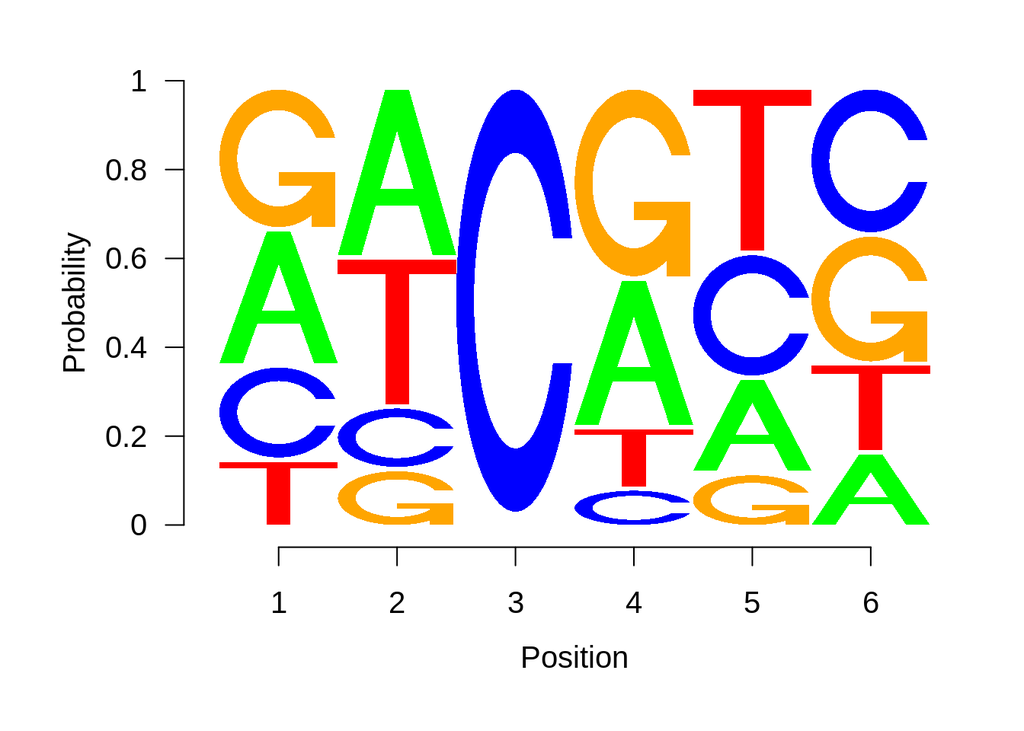

```r
longlogo(model_complex)
```

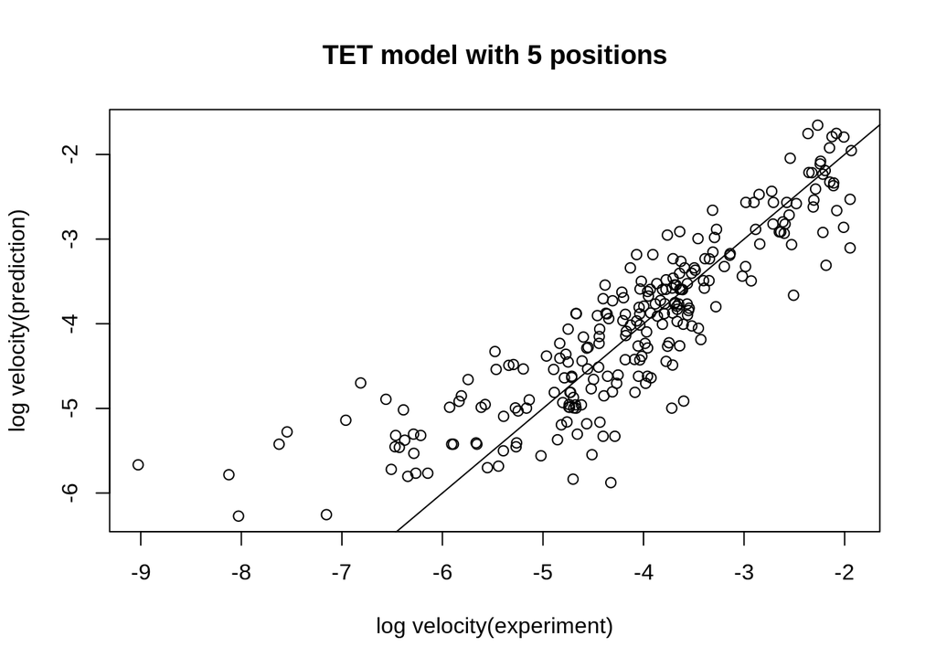

```r
plot(TET_clean$avlogV,as.vector(model_complex$fitted.values),
     main="TET model with 5 positions",
     xlab="log velocity(experiment)",
     ylab="log velocity(prediction)")
abline(a=0,b=1)
```

```r
cor(TET_clean$avlogV,as.vector(model_complex$fitted.values))
```

```
## [1] 0.86475044
```

## Create a model with five contributing bases and weighting, half the data for model

TET_clean_2a will be used to generate the model TET_clean_2b will be used to check the model

```r
ind <- sample(c(TRUE, FALSE), nrow(TET_clean), replace=TRUE, prob=c(0.5, 0.5))
TET_clean_2a<-TET_clean[ind,]
TET_clean_2b<-TET_clean[!ind,]
```

Now build the model with 5 positions and weighting, based on TET_clean_2a

```r
model_complex_sample <-lm(avlogV~V2+V3+V5+V6+V7,data=TET_clean_2a, weights=1/(difflogV+0.1))
summary(model_complex_sample)
```

```
##
## Call:
## lm(formula = avlogV ~ V2 + V3 + V5 + V6 + V7, data = TET_clean_2a,
##     weights = 1/(difflogV + 0.1))
##
## Weighted Residuals:
##       Min        1Q    Median        3Q       Max
## -2.259754 -0.633685 -0.079277  0.381413  2.177297
##
## Coefficients:
##              Estimate Std. Error  t value  Pr(>|t|)
## (Intercept) -2.921029   0.211115 -13.8362 < 2.2e-16 ***
## V2C         -0.354303   0.131061  -2.7033 0.0081615 **
## V2G         -0.022651   0.131195  -0.1726 0.8633024
## V2T         -0.693484   0.152508  -4.5472 1.636e-05 ***
## V3C         -1.211692   0.161414  -7.5067 3.587e-11 ***
## V3G         -1.104203   0.167588  -6.5888 2.628e-09 ***
## V3T         -0.258973   0.159616  -1.6225 0.1080867
## V5C         -1.095370   0.137288  -7.9786 3.756e-12 ***
## V5G          0.545200   0.145461   3.7481 0.0003092 ***
## V5T         -0.715897   0.134041  -5.3409 6.530e-07 ***
## V6C          0.126235   0.160258   0.7877 0.4328758
## V6G         -0.611381   0.162303  -3.7669 0.0002897 ***
## V6T          0.474764   0.158433   2.9966 0.0034998 **
## V7C          0.624737   0.142420   4.3866 3.033e-05 ***
## V7G          0.606251   0.161221   3.7604 0.0002963 ***
## V7T          0.014553   0.164709   0.0884 0.9297857
## ---
## Signif. codes:  0 '***' 0.001 '**' 0.01 '*' 0.05 '.' 0.1 ' ' 1
##
## Residual standard error: 0.8833 on 93 degrees of freedom
## Multiple R-squared:  0.82437,    Adjusted R-squared:  0.79604
## F-statistic: 29.101 on 15 and 93 DF,  p-value: < 2.22e-16
```

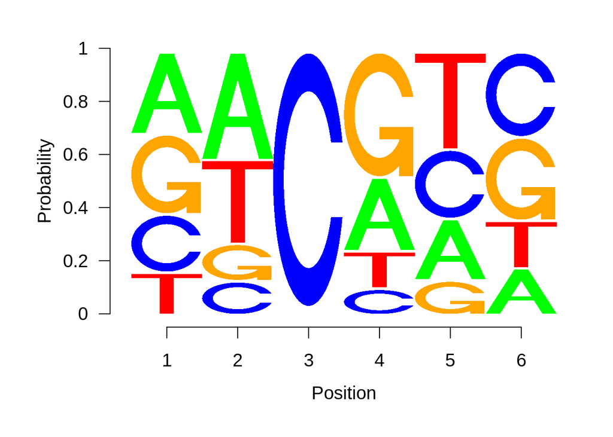

```r
longlogo(model_complex_sample)
```

check how well the model fits the data that have been used for its calculation

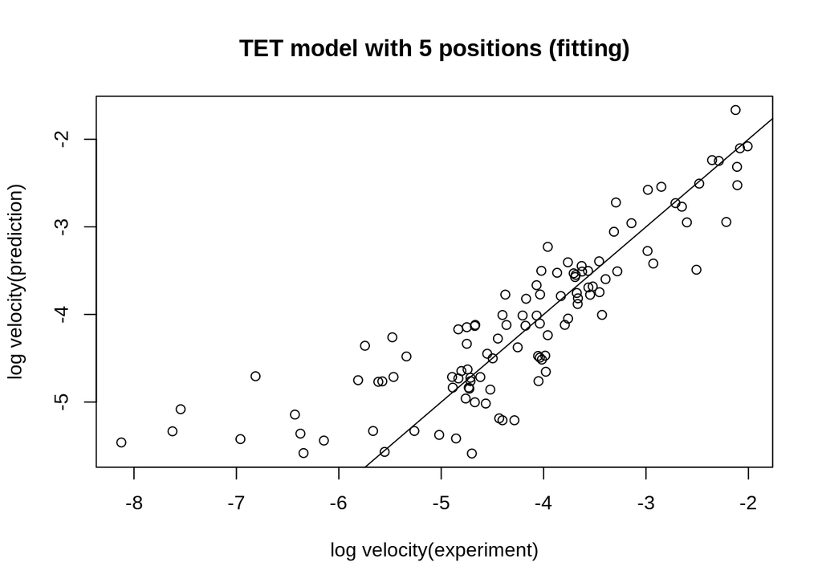

```r
plot(TET_clean_2a$avlogV,predict(model_complex_sample,TET_clean_2a),
     main="TET model with 5 positions (fitting)",
     xlab="log velocity(experiment)",
     ylab="log velocity(prediction)")
abline(a=0,b=1)
```

```r
cor(TET_clean_2a$avlogV,predict(model_complex_sample,TET_clean_2a))
```

```
## [1] 0.84535348
```

check the quality of the model with the other half of the data

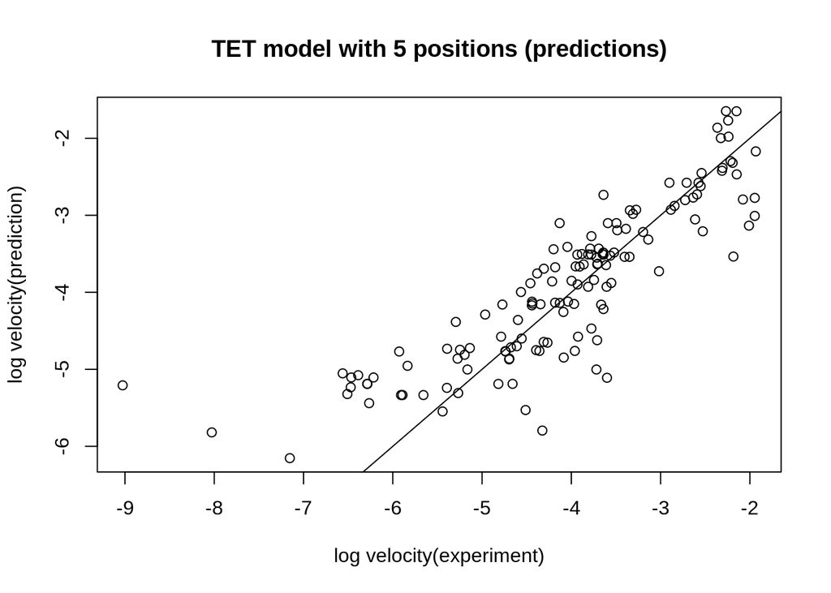

```r
plot(TET_clean_2b$avlogV,predict(model_complex_sample,TET_clean_2b),
     main="TET model with 5 positions (predictions)",
     xlab="log velocity(experiment)",
     ylab="log velocity(prediction)")
abline(a=0,b=1)
```

```r
cor(TET_clean_2b$avlogV,predict(model_complex_sample,TET_clean_2b))
```

```
## [1] 0.85442939
```